# Data Visualization Project 3 Data Storytelling: Open Project

Electric Vehicles: Are they Worth the Hassle?

Merim Tojaga Northeastern University INSH 5302: Information Design and Visual Analytics

December 07, 2024

# Introduction

The data analysis I conducted was both broad and focused when it came to the details of price and time spent charging. I focused on the people collecting the data to highlight the potential bias in the data set and to qualify my assumptions later in the analysis. I created several graphs examining the same metrics to provide a broad view of how these vehicles were being used. I then turned my attention to the details that most readers would care about: time and money. For both of these graphs, I constructed easy-to-read, complex graphs where no extra information is needed to describe the data, but it is provided anyway. All in all, I believe the info graphic I created conveys a relevant message, and the graphs all lead to a clear explanation.

## Data

### Load Libraries and Packages

```r
library(dplyr)
library(moderndive)
library(pheatmap)
library(tidyr)
library(viridis)
library(ggplot2)
library(plot3D)
library(plotly)
library(hexbin)
library(plotrix)
library(treemap)
library(RColorBrewer)
library(reticulate)
library(reticulate)
library(htmlwidgets)
library(mosaic)
```

### Description of data

> Topic or Package: Electric Vehicle Charging. It takes data from 85 users about their experience charging an EV. Has several Metrics ripe for analysis. I wanted this data set because I love cars and am very familiar with all the pros and cons of an Electric Vehicle.

> Data set: EV Charging in Moderndive Package.

### Load and Clean Data

```r
df <- moderndive::ev_charging

df_cleaned <- df %>%
  dplyr::select(-session_id, -created, -ended, -location_id, -manager_vehicle, -platform, -reported_zip, -start_time, -end_time, -station_id)

df_cleaned$user_id <- as.factor(df_cleaned$user_id)
User_ID_counts <- table(df_cleaned$user_id)
user_df <- data.frame(User_ID_counts)
colnames(user_df) <- c("user_id", "count")
df_cleaned <- merge(df_cleaned, user_df, by = "user_id", all.x = TRUE)
```

### Preview Data

```r
head(df_cleaned, 10)
```

| user_id | kwh_total | dollars | charge_time_hrs | weekday | distance | mon | tues | wed | thurs | fri | sat | sun | facility_type | count |
| --- | --- | --- | --- | --- | --- | --- | --- | --- | --- | --- | --- | --- | --- | --- |
| 10427670 | 1.80 | 0 | 2.9336111 | Thu | 1.3751582 | 0 | 0 | 0 | 1 | 0 | 0 | 0 | research and development | 11 |
| 10427670 | 1.65 | 0 | 3.9125000 | Wed | 0.9718696 | 0 | 0 | 1 | 0 | 0 | 0 | 0 | research and development | 11 |
| 10427670 | 3.26 | 0 | 3.9761111 | Thu | 1.3751582 | 0 | 0 | 0 | 1 | 0 | 0 | 0 | research and development | 11 |
| 10427670 | 5.05 | 0 | 3.0908333 | Fri | 0.9718696 | 0 | 0 | 0 | 0 | 1 | 0 | 0 | research and development | 11 |
| 10427670 | 2.31 | 0 | 3.8322222 | Mon | 0.9718696 | 1 | 0 | 0 | 0 | 0 | 0 | 0 | research and development | 11 |
| 10427670 | 5.37 | 0 | 3.4844444 | Thu | 0.9718696 | 0 | 0 | 0 | 1 | 0 | 0 | 0 | research and development | 11 |
| 10427670 | 3.79 | 0 | 3.4427778 | Tue | 1.3751582 | 0 | 1 | 0 | 0 | 0 | 0 | 0 | research and development | 11 |
| 10427670 | 0.00 | 0 | 0.0188889 | Fri | NA | 0 | 0 | 0 | 0 | 1 | 0 | 0 | research and development | 11 |
| 10427670 | 3.78 | 0 | 3.3844444 | Wed | 1.3751582 | 0 | 0 | 1 | 0 | 0 | 0 | 0 | research and development | 11 |
| 10427670 | 0.00 | 0 | 0.0288889 | Fri | NA | 0 | 0 | 0 | 0 | 1 | 0 | 0 | research and development | 11 |

### Variables

```r
colnames(df_cleaned)
```

```
##  [1] "user_id"         "kwh_total"       "dollars"         "charge_time_hrs"
##  [5] "weekday"         "distance"        "mon"             "tues"
##  [9] "wed"             "thurs"           "fri"             "sat"
## [13] "sun"             "facility_type"   "count"
```

The variables featured in this data visualization project are:

1. user_id: ID of the driver
2. kwh_total: kWh used for the charge
3. dollars: USD $ per charge
4. charge_time_hrs: Hours spent charging
5. weekday: Day of the week
6. distance: Miles traveled to charging station
7. mon: encoded 0 1
8. tues: encoded 0 1
9. wed: encoded 0 1
10. thurs:encoded 0 1
11. fri: encoded 0 1
12. sat: encoded 0 1
13. sun: encoded 0 1
14. facility_type: Where charging took place (work)
15. count: Number of trips by that User.
16. Trips_To_Charging_Station: Binned a variable for easier use in the graph. * * *

# Data Analysis

## Required Analysis

### Chart/Graph

```r
binned_values <- cut(df_cleaned$count, breaks = 6)

df_cleaned$Trips_To_Charging_Station <- cut(df_cleaned$count,
                                            breaks = 6, labels = c("Below 30 Trips", "30 to 60 Trips", "60 to 90 Trips", "90 - 130 Trips", "130 - 160 Trips", "Above 160 Trips"))

df_summary <- df_cleaned %>%
  group_by(Trips_To_Charging_Station) %>%
  summarise(
    monday = sum(mon == 1),
    tuesday = sum(tues == 1),
    wednessday = sum(wed == 1),
    thursday = sum(thurs == 1),
    friday = sum(fri == 1),
    saturday = sum(sat == 1),
    sunday = sum(sun == 1)
  )

df_long <- df_summary %>%
  pivot_longer(cols = monday:sunday, names_to = "day", values_to = "count")


heat_map <- ggplot(df_long, aes(x = day, y = Trips_To_Charging_Station, fill = count)) +
  geom_tile() +
  scale_fill_viridis() +  # Color scale for heatmap
  labs(title = "Weekly Charging Activity of EV Drivers", x = "Day of the Week", y = "Trips To Charging Station") +
  theme_minimal() +
  theme(axis.text.x = element_text(angle = 45, hjust = 1))

ggsave("heat_map.png", plot = heat_map, width = 6, height = 4, dpi = 300)
```

```r
df_cleaned$charge_time_hrs <- round(df_cleaned$charge_time_hrs, 2)
df_cleaned <- df_cleaned %>%
  filter(charge_time_hrs < 55)

scatter_ev <- ggplot(df_cleaned, aes(x= kwh_total, y= charge_time_hrs)) + geom_point(color = "yellow2", size = 1.2) +
  geom_smooth(method = "lm", se = FALSE, color = "springgreen3", size = 1.4) + labs(
    title = "Relationship Between Total kWh and Charge Time",
    subtitle = "A plot showing the correlation between kWh total and charge time in hours",
    x = "Total kWh",
    y = "Charge Time (hrs)"
  ) + theme_dark(base_size = 14)
ggsave("scatter_ev.png", plot = scatter_ev, width = 8, height = 4, dpi = 300)
df_pie <- df_cleaned %>%
  group_by(weekday) %>%
  summarise(
    Overall_Charge_timeHrs = sum(charge_time_hrs)
  )

# Create the 3D pie chart using plot_ly
donut_ev <- plot_ly(df_pie, labels = ~weekday, values = ~Overall_Charge_timeHrs, type = "pie",
        textinfo = "label+percent", rotation = 90,
        hole = 0.3,
        marker = list(
          colors = viridis::viridis(length(df_pie$Overall_Charge_timeHrs))  # Apply Viridis color scale
        )) %>%
  layout(
    title = "Donut Chart of KWh in the Data Separated by Weekday",
    showlegend = TRUE,
    scene = list(
      camera = list(eye = list(x = 1, y = 1, z = 1))  # Controls the 3D view angle
    ),
    paper_bgcolor = "rgba(0,0,0,0)",  # Transparent background
    plot_bgcolor = "rgba(0,0,0,0)"    # Transparent plot background
  )

saveWidget(donut_ev, "donutev_interactive.html")
```

```r
par(mar = c(5, 5, 2, 2))
png("larger_hexbin_plot.png", width = 1000, height = 800, res = 100)
bins = hexbin(df_cleaned$dollars, df_cleaned$distance, xbins = 20)
smb = smooth.hexbin(bins)
plot(smb, colramp = viridis,
     main = "Hex Plot of Price Per Charging vs Distance Traveled by Driver",
     xlab = "Distance Traveled in Miles",
     ylab = "Price of Charge in USD($)")
```

```r
df_pyramid <- df_cleaned %>%
  group_by(facility_type) %>%
  summarise(
    kWh = sum(kwh_total),
    charge_time = sum(charge_time_hrs)
  )

png("pyramid_plot.png", width = 1000, height = 800, res = 100)
pyramid.plot(df_pyramid$kWh, df_pyramid$charge_time,labels= df_pyramid$facility_type,
unit = NA, gap = 0,laxlab=c(0,5,10,15),
 raxlab=c(0,5,10,15), top.labels = c("Total Kilowatts (KWh)",
 "Facility Type", "Time Spent Charging (Hours)"),lxcol = "darkseagreen3",rxcol = "khaki")
```

```
## 10704 10704
```

```
## [1] 5.1 4.1 4.1 2.1
```

```r
palette <- brewer.pal(n = 5, name = "Set3")
tm <- treemap(df_pyramid,
              index = c("facility_type", "kWh", "charge_time"),
              vSize = "charge_time",
              vColor = "kWh",
              palette = palette)
```

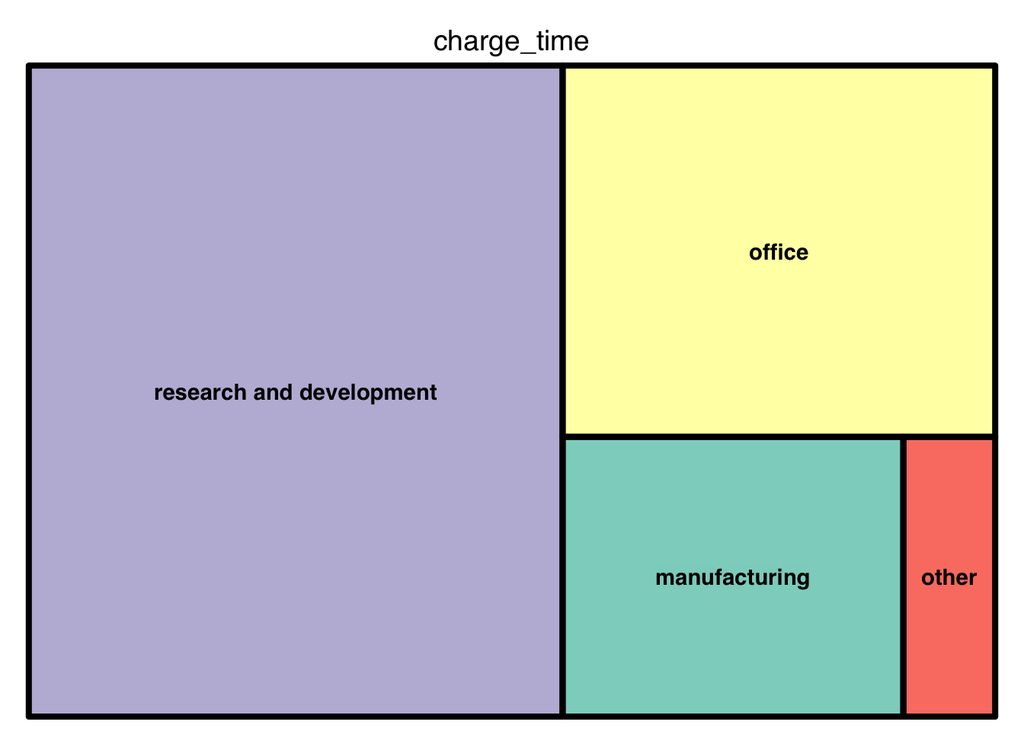

```r
png("treemap_plot.png", width = 800, height = 600)

fig_tree <- plot_ly(
  type = "treemap",
  labels = df_pyramid$facility_type,
  parents = df_pyramid$charge_time,
  values = df_pyramid$charge_time,
  textinfo = "label+value",
  marker = list(colors = brewer.pal(5, "Set3"))
)

saveWidget(donut_ev, "donutev_interactive.html")
```

### Summary Statistics

```r
favstats(df_cleaned$dollars)
```

|  | min | Q1 | median | Q3 | max | mean | sd | n | missing |
| --- | --- | --- | --- | --- | --- | --- | --- | --- | --- |
|  | 0 | 0 | 0 | 0 | 7.5 | 0.1180583 | 0.4924829 | 3394 | 0 |

```r
favstats(df_cleaned$kwh_total)
```

|  | min | Q1 | median | Q3 | max | mean | sd | n | missing |
| --- | --- | --- | --- | --- | --- | --- | --- | --- | --- |
|  | 0 | 4.35 | 6.23 | 6.83 | 23.68 | 5.810133 | 2.893005 | 3394 | 0 |

```r
favstats(df_cleaned$charge_time_hrs)
```

|  | min | Q1 | median | Q3 | max | mean | sd | n | missing |
| --- | --- | --- | --- | --- | --- | --- | --- | --- | --- |
|  | 0.01 | 2.11 | 2.81 | 3.54 | 11.59 | 2.826022 | 1.209825 | 3394 | 0 |

# Option 1: Infographic Poster

Attached your completed Infographic Poster as a PNG, JPEG, or PDF file attached to the file submission portal.

[interactive chart not shown]

[Electric Vehicles](https://www.canva.com/design/DAGYliqtvm0/6icMuNMkV6bsm6vkNiLRAg/view?utm_content=DAGYliqtvm0&utm_campaign=designshare&utm_medium=embeds&utm_source=link) by Tojaga M

URL Link to Canva Viz Site: [Merim Tojaga - Data Viz Project 3](https://www.canva.com/design/DAGYliqtvm0/6icMuNMkV6bsm6vkNiLRAg/view)

# References

1. https://search.r-project.org/CRAN/refmans/moderndive/html/ev_charging.html
2. https://pod-point.com/guides/driver/how-long-to-charge-an-electric-car#:~:text=A%20typical%20electric%20car%20(60kWh,with%20a%2050kW%20rapid%20charger.
3. https://www.nytimes.com/2022/09/01/us/california-heat-wave-flex-alert-ac-ev-charging.html

# All done!

Knit the completed R Markdown file as a HTML document (click the “Knit” button at the top of the script editor window) and upload it to the submission portal on Canvas.